# Meeting 9 - Intro to Hypothesis Testing

Matthew E. Aiello-Lammens

2020-04-01

# Hypothesis Testing

- What is a hypothesis?
- How do we test our hypothesis?

The answers to these questions, with respect to this course, are primarily based on frequentest statistics.

## Example

Let’s say we have a sample of observations that we want to know if they come from some population with a known value for $\mu$ (i.e., we know the population mean). We can see how (un)likely it is that the sample estimates come from this particular population, by looking at where these values fall in a *t* distribution. That is, calculate the *t* statistic:

$$t_s = \frac{\bar{y} - \mu}{s_{\bar{y}}}$$

### ASIDE: Why are we using the *t* distribution?

We are using the *t* distribution because we are using an approximation of standard error, $s_{\bar{y}}$, based on data in our sample.

## *t*-test

- Looking at differences between two samples of data. The *differences* should be *t* distributed.
- **Major assumptions** - the samples are drawn from populations that are:
  1. (Approximately) normally distributed
  2. Equally varied (i.e. equal variance)
  3. Each observation is *independent*

## We select the Type-I error rate

General Consensus is $p = 0.05$. This is known as Type-I error, or $\alpha$.

### Type-I versus Type-II error

- **Type-I error: $\alpha$** - our test suggests there is an effect, but there really is not one
- **Type-II error: $\beta$** - when you fail to detect an effect that really occurs

### Statistical power

The reciprocal of Type-II error ($\beta$) is **power**.

$$power(1-\beta) \propto \frac{ES \sqrt{n} \alpha}{\sigma}$$

where $ES$ is *effect size*, $n$ is the sample size, $\alpha$ is the accepted Type I error rate, and $\sigma$ is the standard deviation.

#### How do we increase statistical power?

Increase the sample size.

- Distribution of the mean becomes narrower
- Acceptance region becomes narrower
- Curves overlap less
- Type II error rate becomes smaller

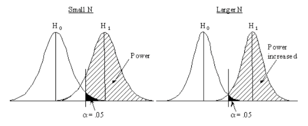

power

## What are the general steps to hypothesis testing?

See p. 33-34 in Q&K. Fisher’s approach below:

- Construct null hypothesis ($H_0$)
- Choose a test stat that measures deviation from null
- Collect data and compare the value of the test stat to the known distribution of that stat.
- Determine p-val
- Accept or reject null

What are some of the potential problems with this approach?

### Our data or something more extreme

When we use a sampling distribution for our test statistic (e.g., the *t* distribution), we are asking “what is the probability of observing our data, or something more extreme, in the long run, if $H_0$ is true.” Mathematically, this can be written as:

$$P(data|H_0)$$

## Generic “test” statistics

Below is the generic form of the *t* statistic:

$$t_s = \frac{St - \theta}{S_{St}}$$

where $St$ is the value of some statistic (e.g., the mean) from our **sample**, $\theta$ is the **population** value for that statistic, and $S_{St}$ is the estimated standard error of the statistic $St$ (based on our sample).

## Comparing two samples

How can we use this formula to test whether two samples are drawn from the same population?

Imagine the case where we have two different samples, and for each we’re testing whether the means are different from the population means. We then have:

$$t_1 = \frac{\bar{y_1}-\mu_1}{s_{\bar{y}_1}}$$

and

$$t_2 = \frac{\bar{y_2}-\mu_2}{s_{\bar{y}_2}}$$

If the two samples are drawn from the same population, then $\mu_1 = \mu_2$, or $\mu_1 - \mu_2 = 0$.

We can then write our *t* stat as:

$$t = \frac{(\bar{y_1} - \bar{y_2}) - (\mu_1 - \mu_2)}{s_{\bar{y}_1 - \bar{y}_2}}$$

which simplifies to:

$$t = \frac{\bar{y_1} - \bar{y_2}}{s_{\bar{y}_1 - \bar{y}_2}}$$

where $s_{\bar{y}_1 - \bar{y}_2}$ is the standard error of the difference between the means and is equal to:

$$s_{\bar{y}_1 - \bar{y}_2} =
\sqrt{
\frac{(n_1-1)s_1^2 + (n_2-1)s_2^2}{n_1 + n_2 -2}
(\frac{1}{n_1} + \frac{1}{n_2})
}$$

# Example of parametric hypothesis testing

## Differences in fecundity of intertidal gastropods in two different intertidal zones (Example 6A in Logan, Box 3.1 in Q&K)

Ward and Quinn (1988) investigated the differences in fecundity of *Lepsiella vinosa* in two different intertidal zones (mussel zone and littorinid zone).

[*Lepsiella vinosa* image](https://images.app.goo.gl/Mjdu8xaaxafPz1nC6)

Get the data and have a quick look

```r
gastro <- read.csv(file = "https://mlammens.github.io/ENS-623-Research-Stats/data/Logan_Examples/Chapter6/Data/ward.csv")
summary(gastro)
```

```
##      ZONE         EGGS
##  Littor:37   Min.   : 5.00
##  Mussel:42   1st Qu.: 8.50
##              Median :10.00
##              Mean   :10.11
##              3rd Qu.:12.00
##              Max.   :18.00
```

Make a box plot to help assess differences in variance and deviations from normality.

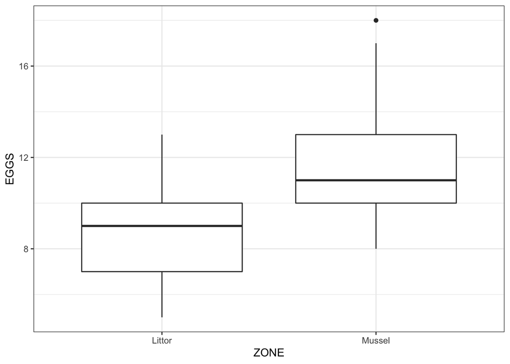

```r
library(ggplot2)

ggplot() +
  geom_boxplot(data = gastro, aes(x = ZONE, y = EGGS)) +
  theme_bw()
```

Calculate means and standard deviations of each group separately. We will be using `dplyr` for this.

```r
library(dplyr)
gastro_summary <-
  gastro %>%
  group_by(ZONE) %>%
  summarise(Mean = mean(EGGS),
            Var = var(EGGS),
            SD = sd(EGGS),
            SE = sd(EGGS)/sqrt(length(ZONE)))

gastro_summary
```

```
## # A tibble: 2 x 5
##   ZONE    Mean   Var    SD    SE
##   <fct>  <dbl> <dbl> <dbl> <dbl>
## 1 Littor  8.70  4.10  2.03 0.333
## 2 Mussel 11.4   5.36  2.31 0.357
```

### Calculate the *t* stat by hand, using the equations above

First, let’s calculate $s_{\bar{y}_1 - \bar{y}_2}$ using the formula noted above:

```r
n_littor <- sum(gastro$ZONE == "Littor")
n_mussel <- sum(gastro$ZONE == "Mussel")

sd_littor <- gastro_summary$SD[1]
sd_mussel <- gastro_summary$SD[2]

s_1_2 <- sqrt( (((n_littor - 1)*sd_littor^2 + (n_mussel - 1)*sd_mussel^2 )/
                  (n_littor + n_mussel -2)) *
                 ((1/n_littor) + (1/n_mussel)) )

mean_littor <- gastro_summary$Mean[1]
mean_mussel <- gastro_summary$Mean[2]

tstat <- (mean_littor - mean_mussel) / s_1_2
```

OK, now we have our *t* statistic. In order to use this to say something about the probability that these two sample come from a population with the same mean, we need to know what degrees of freedom to use to parameterize our *t* distribution. Here’s the simple formula:

$$df = (n_1 - 1) + (n_2 - 1)$$

So now we can say that the *df* here is:

```r
df_gastro <- (n_littor - 1) + (n_mussel - 1)
```

```r
pt(q = tstat, df = df_gastro) * 2
```

```
## [1] 7.457222e-07
```

The resulting probability value is **very** small, much less than 0.05. In this case, we would **reject the null hypothesis** that these two samples come from the same population.

### Use R’s native `t.test` function

```r
(gastro_t_test <- t.test(data = gastro, EGGS ~ ZONE, var.equal = TRUE))
```

```
##
##  Two Sample t-test
##
## data:  EGGS by ZONE
## t = -5.3899, df = 77, p-value = 7.457e-07
## alternative hypothesis: true difference in means is not equal to 0
## 95 percent confidence interval:
##  -3.63511 -1.67377
## sample estimates:
## mean in group Littor mean in group Mussel
##             8.702703            11.357143
```

```r
gastro_t_test$estimate[1] - gastro_t_test$estimate[2]
```

```
## mean in group Littor
##             -2.65444
```

# Dealing with violations of assumptions

Recall our **Major assumptions for using a *t* test** - the samples are drawn from populations that are:

1. (Approximately) normally distributed
2. Equally varied (i.e. equal variance)
3. Each observation is *independent*

Let’s say our data don’t fit the assumptions of the *t* test. What are our options?

**NOTE: I’ve posted videos on Blackboard the work through each of the three examples below.**

## Paired *t*-test

A paired *t*-test provides one way to deal with data that are not independent. But the cases it can be applied in are fairly limited.

To demonstrate the paired *t*-test, let’s examine Example 6C in the Logan 2010 text book. This example relates to a paper by Elgar et al. 1996, where the researchers examined the width and height of orb-spinning spider webs in two different light conditions, light and dark. Each spider in the study was examined in both light and dark conditions, which means that the light and dark measurements were **not independent** from each other. Therefore, the authors employed a paired *t*-test. Below we work through this example.

Read in the data.

```r
orb_spider <- read.csv("https://mlammens.github.io/ENS-623-Research-Stats/data/Logan_Examples/Chapter6/Data/elgar.csv")
```

Calculate the difference columns for both width (horizontal) and height (vertical).

```r
orb_spider$VERT_DIFF <- orb_spider$VERTDIM - orb_spider$VERTLIGH
orb_spider$HORIZ_DIFF <- orb_spider$HORIZDIM - orb_spider$HORIZLIG
```

Calculate the mean and standard error values

```r
vert_diff_mean <- mean(orb_spider$VERT_DIFF)
horiz_diff_mean <- mean(orb_spider$HORIZ_DIFF)
```

```r
vert_diff_se <- sd(orb_spider$VERT_DIFF) / sqrt(nrow(orb_spider))
horiz_diff_se <- sd(orb_spider$HORIZ_DIFF) / sqrt(nrow(orb_spider))
```

Calculate T-stat

```r
vert_diff_T <- (vert_diff_mean - 0) / vert_diff_se
horiz_diff_T <- (horiz_diff_mean - 0) / horiz_diff_se
```

Calculate p-vals

```r
2*pt(q = vert_diff_T, df = (17-1), lower.tail = FALSE)
```

```
## [1] 0.3486872
```

```r
2*pt(q = horiz_diff_T, df = (17-1), lower.tail = FALSE)
```

```
## [1] 0.04735437
```

Now try using `t.test` function

```r
t.test(x = orb_spider$VERTDIM, y = orb_spider$VERTLIGH, paired = TRUE)
```

```
##
##  Paired t-test
##
## data:  orb_spider$VERTDIM and orb_spider$VERTLIGH
## t = 0.96545, df = 16, p-value = 0.3487
## alternative hypothesis: true difference in means is not equal to 0
## 95 percent confidence interval:
##  -24.61885  65.79532
## sample estimates:
## mean of the differences
##                20.58824
```

```r
t.test(x = orb_spider$HORIZDIM, y = orb_spider$HORIZLIG, paired = TRUE)
```

```
##
##  Paired t-test
##
## data:  orb_spider$HORIZDIM and orb_spider$HORIZLIG
## t = 2.1482, df = 16, p-value = 0.04735
## alternative hypothesis: true difference in means is not equal to 0
## 95 percent confidence interval:
##   0.6085725 91.7443687
## sample estimates:
## mean of the differences
##                46.17647
```

## Non-parametric Rank based tests - Mann-Whitney / Wilcoxon test

Rank based tests are good to use if our data do not fit the assumption of normality and cannot be easily transformed, but do fit the assumption of approximately equal variance.

Look at ranks, rather than actual values.

From Q&K p. 47:

1. Rank all observations, ignoring groups. Tied observations get the average of their ranks.
2. Calculate the sum of the ranks for both samples. If $H_0$ is true, then you should expect similar sums.
3. Compare the smaller rank sum to the probability distribution of rank sums, based on repeated randomization of observations to groups.
4. If sample sizes are large, the probability distribution of rank sums approximates a normal distribution and the *z* statistic can be used.

To demonstrate the Mann-Whitney / Wilcoxon test, let’s look at Example 6D from Logan 2010. This example analyzes data presented in Sokal and Rohlf (1997), which happens to be the book I used when learning Biometry. These data include measurements of the sizes of two different samples of chiggers. The question is, do these chiggers have the same mean size values? That is, do they come from the same population?

Load the data set.

```r
chigger <- read.csv("https://mlammens.github.io/ENS-623-Research-Stats/data/Logan_Examples/Chapter6/Data/nymphs.csv")
```

Make a box plot.

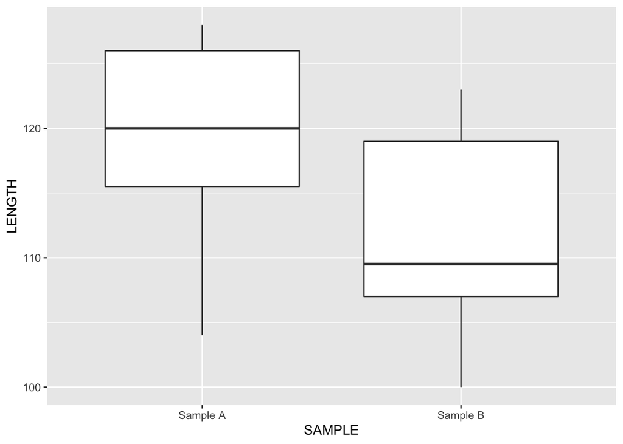

```r
library(ggplot2)
ggplot(data = chigger, aes(x = SAMPLE, y = LENGTH)) +
  geom_boxplot()
```

Make a histogram for each sample

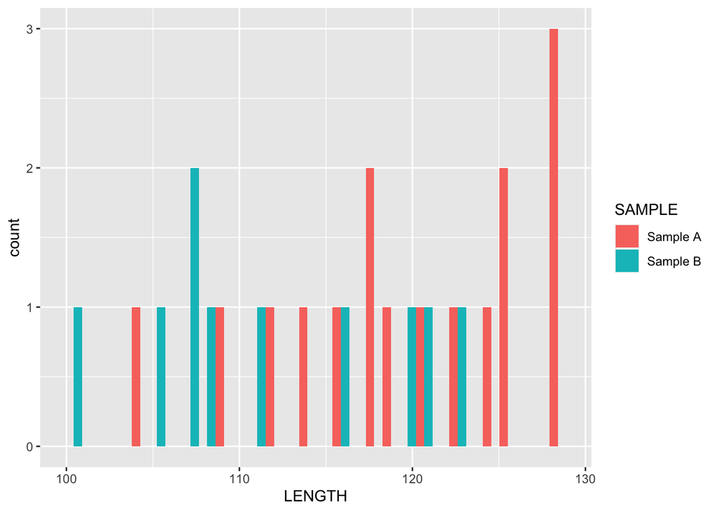

```r
ggplot(data = chigger, aes(x = LENGTH, fill = SAMPLE)) +
  geom_histogram(position = "dodge")
```

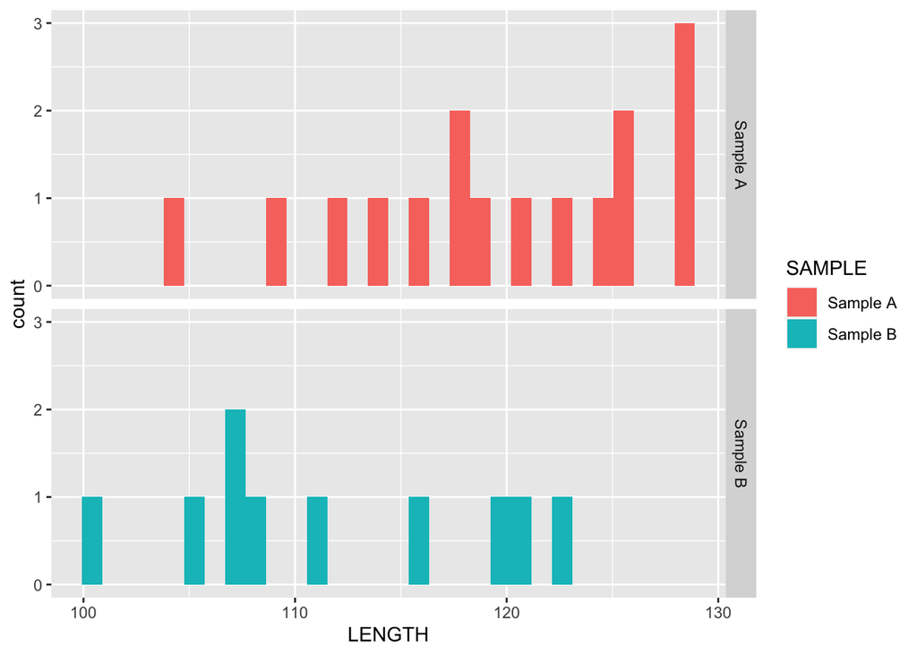

```r
ggplot(data = chigger, aes(x = LENGTH, fill = SAMPLE)) +
  geom_histogram(position = "dodge") +
  facet_grid(SAMPLE~.)
```

Look at the Q-Q plots. Q-Q plots are a diagnostic tool to visually see deviations from normality. Normal data should appear along the straight line.

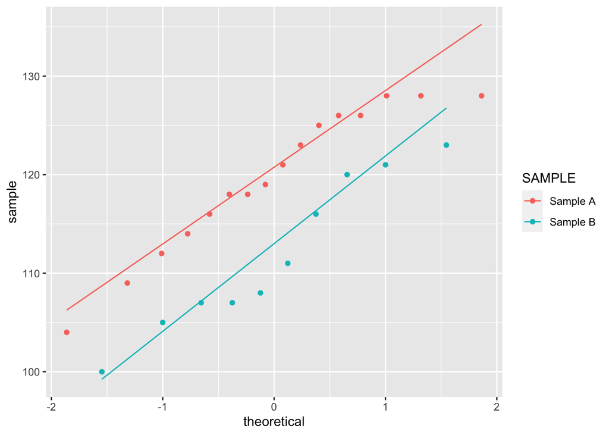

```r
ggplot(data = chigger, aes(sample = LENGTH, color = SAMPLE)) +
  geom_qq() +
  geom_qq_line()
```

Neither of these is normally distributed, so we use a non-parametric test.

```r
wilcox.test(chigger$LENGTH~chigger$SAMPLE)
```

```
##
##  Wilcoxon rank sum test with continuity correction
##
## data:  chigger$LENGTH by chigger$SAMPLE
## W = 123.5, p-value = 0.0232
## alternative hypothesis: true location shift is not equal to 0
```

If we consider our standard $p < 0.05$ threshold for rejecting our null hypothesis, then we see that in this case, we should reject the null hypothesis that these two samples of chiggers are from the same population.

You can find more information on non-parametric tests [here](https://www.statmethods.net/stats/nonparametric.html) and [here](http://rcompanion.org/handbook/F_01.html).

## Randomization tests

Randomization tests are good to use when our data do not fit either the assumption of normality or equal variance.

Get the data and look at it

```r
lizard <- read.csv(file = "https://mlammens.github.io/ENS-623-Research-Stats/data/Logan_Examples/Chapter6/Data/beetle.csv")
head(lizard)
```

```
##    SIZE BEETLES
## 1 small     256
## 2 small     209
## 3 small       0
## 4 small       0
## 5 small       0
## 6 small      44
```

```r
summary(lizard)
```

```
##     SIZE       BEETLES
##  large:21   Min.   :  0.0
##  small:24   1st Qu.:  0.0
##             Median : 34.0
##             Mean   :112.7
##             3rd Qu.:179.0
##             Max.   :843.0
```

Have a look at the box plots for these data.

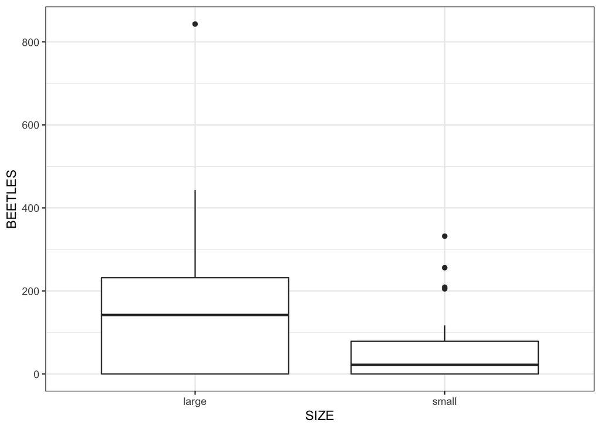

```r
library(ggplot2)

ggplot() +
  geom_boxplot(data = lizard, aes(x = SIZE, y = BEETLES) ) +
  theme_bw()
```

Let’s also look at the histograms of these data

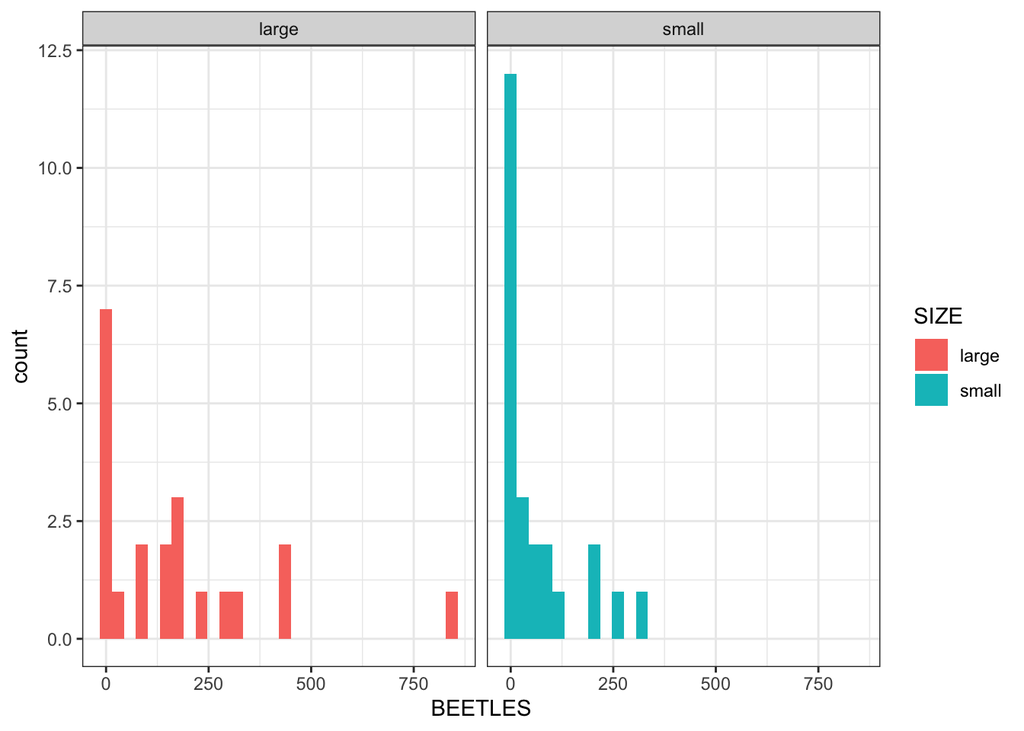

```r
ggplot() +
  geom_histogram(data = lizard, aes(x = BEETLES, fill = SIZE) ) +
  facet_grid( . ~ SIZE ) +
  theme_bw()
```

#### Challenge

What do you observe here that seems like a strong violation to the assumptions of a *t* test?

#### Major Challenge

1. Calculate the *t*-statistic for differences in number of beetles consumed by the two size classes of lizards.
2. Randomize/ shuffle the data.
3. Calculate the **new** *t*-statistic. Repeat this 999 times.
4. How does the observed *t*-stat compare to the generated *t*-stats?

```r
## Run t-test
t.test(data = lizard, BEETLES ~ SIZE)
```

```
##
##  Welch Two Sample t-test
##
## data:  BEETLES by SIZE
## t = 2.1907, df = 27.015, p-value = 0.03728
## alternative hypothesis: true difference in means is not equal to 0
## 95 percent confidence interval:
##    6.862606 209.577870
## sample estimates:
## mean in group large mean in group small
##           170.42857            62.20833
```

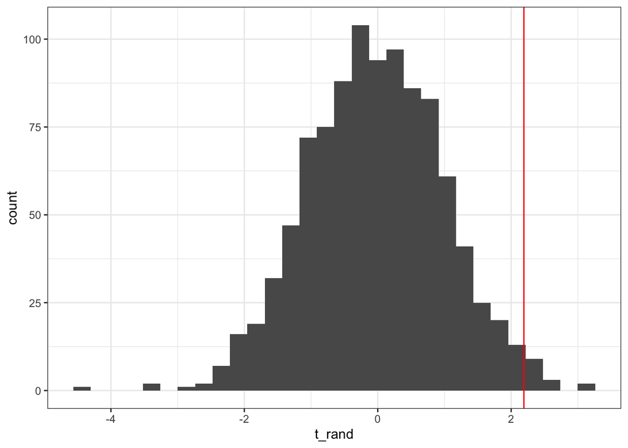

```r
## Record the original t-stat
t_orig <- t.test(data = lizard, BEETLES ~ SIZE)$statistic

## Initiate vector of new t-stat values
t_rand <- c()

## Set the number of reps (shuffles) we want to use
reps <- 1000

## Begin for loop to randomize data
for ( int in 1:reps){

  ## Shuffle the data
  lizard_shuffled <- data.frame(SIZE = sample(lizard$SIZE), BEETLES = lizard$BEETLES)

  ## Run the t-test on the new data, and save the t-stat to the t_rand vector
  t_rand <- c( t_rand,
               t.test(data = lizard_shuffled, BEETLES ~ SIZE)$statistic )

}

ggplot() +
  geom_histogram(data = NULL, aes(x = t_rand)) +
  geom_vline(xintercept = t_orig, colour = "red") +
  theme_bw()
```

To calculate how likely our original *t* statistic is, look at how many values are more extreme. Remember to check both tails.

```r
t_rand_extreme <- sum(abs(t_rand) > t_orig)

(p_t_orig <- t_rand_extreme/ reps)
```

```
## [1] 0.027
```

# Multiple testing

- If you perform a single hypothesis test, using $\alpha = 0.05$, what is the probability that you reject the null hypothesis, even though the null is correct?

The probability of a *significant result by chance* is p = 0.05.

- If you perform 20 hypothesis tests, using $\alpha = 0.05$, what is the probability that in at least one of those cases, you will reject the null hypothesis, even though it is correct?

Here, we are looking for the probability of *at least one significant result by chance*, which we can write probablistically as:

P(at least one significant result) = 1 - P(no significant results)

Next, let’s note that the P(no significant result) = 1 - P(significant result), which is 1 - 0.05.

Put this all together and we see that:

$$P(\text{at least one significant result}) = 1 - (1 - 0.05)^{20} \approx 0.64$$

**Note:** Some information above is based on material found at https://www.stat.berkeley.edu/~mgoldman/Section0402.pdf.

From Quinn and Keough, p. 48:

> One of the most difficult issues related to statistical hypothesis testing is the potential accumulation of decision errors under circumstances of multiple testing.

### Example of problems with multiple comparisons

```r
my_data <- list()
for (i in 1:20) {
    my_data[[i]] <- rnorm(10)  #Note the double brackets for a list
}
```

Run a *t* test for all possible pair-wise comparisons. **This results in 190 pair-wise comparisons.

```r
p_vals <- matrix(ncol = 20, nrow = 20)
for (i in 1:19) {
    for (j in (i + 1):20) {
        p_vals[i, j] <- t.test(my_data[[i]], my_data[[j]])$p.value
    }
}
p_vals
```

```
##       [,1]      [,2]      [,3]      [,4]      [,5]      [,6]      [,7]
##  [1,]   NA 0.9195874 0.9972560 0.9205550 0.8191047 0.5729758 0.6027662
##  [2,]   NA        NA 0.9271595 0.8509058 0.8905645 0.4996737 0.5389015
##  [3,]   NA        NA        NA 0.9215458 0.8309564 0.5920238 0.6159986
##  [4,]   NA        NA        NA        NA 0.7673220 0.6962804 0.7057516
##  [5,]   NA        NA        NA        NA        NA 0.4460941 0.4840761
##  [6,]   NA        NA        NA        NA        NA        NA 0.9767364
##  [7,]   NA        NA        NA        NA        NA        NA        NA
##  [8,]   NA        NA        NA        NA        NA        NA        NA
##  [9,]   NA        NA        NA        NA        NA        NA        NA
## [10,]   NA        NA        NA        NA        NA        NA        NA
## [11,]   NA        NA        NA        NA        NA        NA        NA
## [12,]   NA        NA        NA        NA        NA        NA        NA
## [13,]   NA        NA        NA        NA        NA        NA        NA
## [14,]   NA        NA        NA        NA        NA        NA        NA
```

[output cut: 48 more lines]

How many are false positives?

```r
sum(p_vals < 0.05, na.rm = TRUE)
```

```
## [1] 0
```

There are a number of ways to address the multiple comparison problem. One approach, which we will learn in the coming weeks, is to use Analysis of Variance (ANOVA) when appropriate. Another, is to adjust the $\alpha$ value we use to accept / reject our null hypothesis. There are multiple ways to adjust the $\alpha$ value; I recommend looking at the help for the function `p.adjust`. One of the most common methods is the [**Bonferroni Correction**](https://en.wikipedia.org/wiki/Bonferroni_correction), which is:

$$\frac{\alpha}{m}$$

where $m$ is the number of different tests.

So for our example above, we would use:

```r
new_alpha <- 0.05 / 190
new_alpha
```

```
## [1] 0.0002631579
```

And using this new value we can look for how many false positives there are:

```r
sum(p_vals < new_alpha, na.rm = TRUE)
```

```
## [1] 0
```